# CIND 123: Data Analytics Basic Methods: Assignment-3

## Question 3 [15 Pts]

This question makes use of package “ISwR”. Please load `airquality` dataset as following:

```r
#install.packages("ISwR")
library(ISwR)
data(airquality)
str(airquality)
```

```
## 'data.frame':    153 obs. of  6 variables:
##  $ Ozone  : int  41 36 12 18 NA 28 23 19 8 NA ...
##  $ Solar.R: int  190 118 149 313 NA NA 299 99 19 194 ...
##  $ Wind   : num  7.4 8 12.6 11.5 14.3 14.9 8.6 13.8 20.1 8.6 ...
##  $ Temp   : int  67 72 74 62 56 66 65 59 61 69 ...
##  $ Month  : int  5 5 5 5 5 5 5 5 5 5 ...
##  $ Day    : int  1 2 3 4 5 6 7 8 9 10 ...
```

1. [5 Pts] Plot a histogram to assess the normality of the `Solar.R` variable, then explain why it does not appear normally distributed.

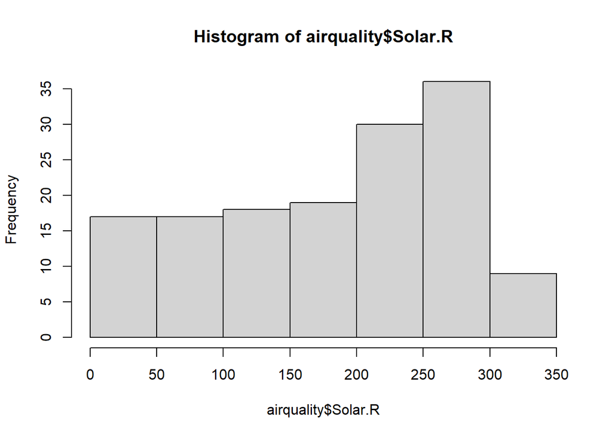

```
## $breaks
## [1]   0  50 100 150 200 250 300 350
##
## $counts
## [1] 17 17 18 19 30 36  9
##
## $density
## [1] 0.002328767 0.002328767 0.002465753 0.002602740 0.004109589 0.004931507
## [7] 0.001232877
##
## $mids
## [1]  25  75 125 175 225 275 325
##
## $xname
## [1] "airquality$Solar.R"
##
## $equidist
## [1] TRUE
##
## attr(,"class")
## [1] "histogram"
```

```r
print(hist(airquality$Solar.R))
```

```r
#This variable does not appear normally distributed because the histogram is not a bell shaped curve (the mean, median, and mode do not appear to be centered with a symmetrical distribution on either side), rather, the data appears to be left-skewed.
```

2. [5 Pts] Create a boxplot that shows the distribution of `Solar.R` in each month. Use different colors for each month.

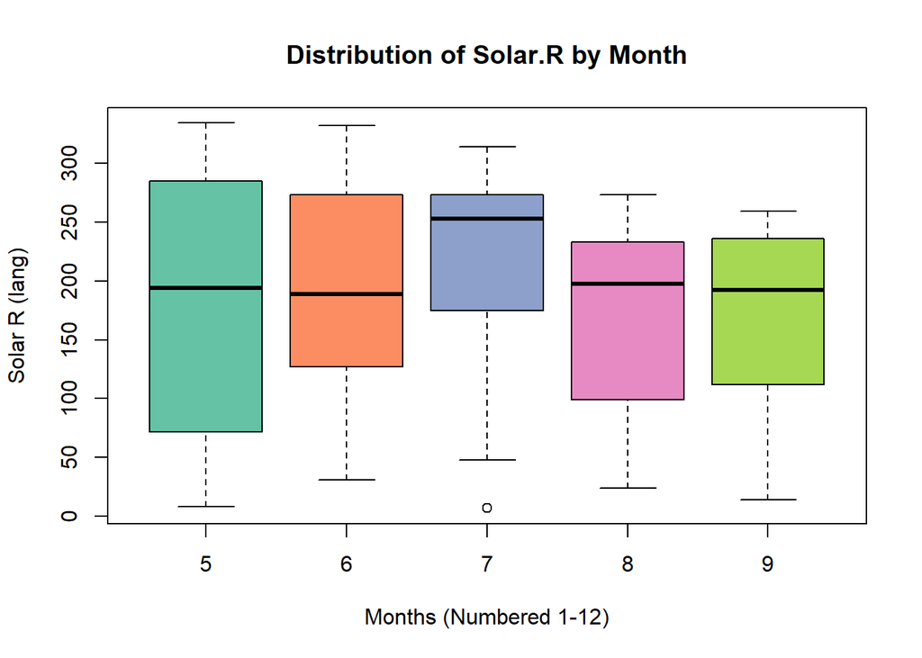

```r
#Colour vector preparation
library (RColorBrewer)

boxplot(Solar.R ~ Month, data = airquality, main = "Distribution of Solar.R by Month", xlab = "Months (Numbered 1-12)", ylab = "Solar R (lang)", col= brewer.pal(12, name = "Set2"))
```

3. [5 Pts] Create a matrix of scatterplots of all the numeric variables in the `airquality` dataset (i.e. Ozone, Solar.R, Wind and Temp.) (Hint: investigate pairs() function)

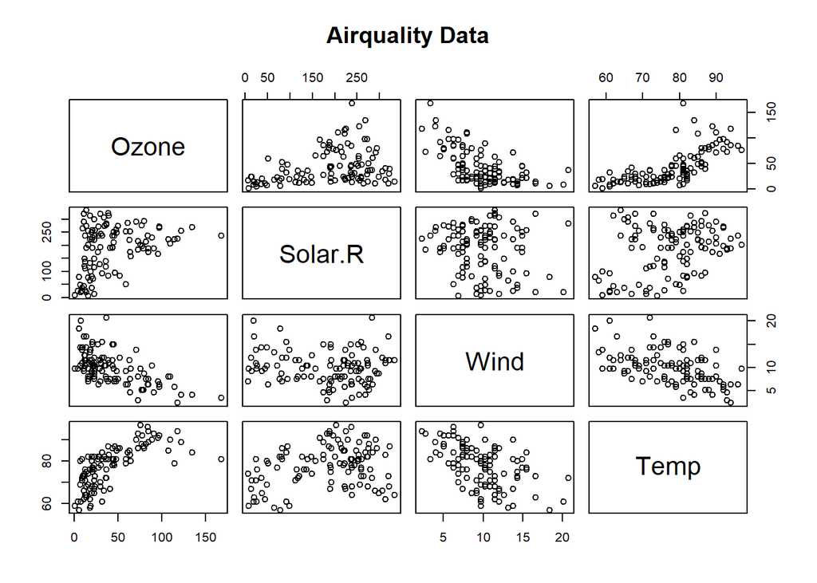

```r
#Matrix only comparing: Ozone, Solar.R, Wind and Temp
print(pairs(~ Ozone + Solar.R + Wind + Temp, data = airquality, main = "Airquality Data", na.action = na.omit))
```

## Question 4 [25 Pts]

Many times in data analysis, we need a method that relies on repeated random sampling to obtain numerical results. The underlying concept is to use randomness to solve problems. In fact, this is a mathematical technique, which is used to estimate the possible outcomes of an uncertain event and is called the *Monte Carlo Method*.

Consider that We roll a die 10 times and we want to know the probability of getting more than 3 times of even numbers. This is a problem for the Binomial distribution, but suppose we don’t know anything about Binomial distribution. We can easily solve this problem with a Monte Carlo Simulation.

1. [5 Pts] The Monte Carlo Method uses random numbers to simulate some process. Here the process is rolling a die 10 times. Assume the die is fair. What is the probability of success or getting an even number in rolling the die once?

```r
#install.packages("gtools")
library(gtools)
one.dice <- c(1, 2, 3, 4, 5, 6)
perm <- permutations(length(one.dice), 1, one.dice,
repeats.allowed =TRUE)
perm
```

```
##      [,1]
## [1,]    1
## [2,]    2
## [3,]    3
## [4,]    4
## [5,]    5
## [6,]    6
```

```r
#Probability of success of rolling an even number when rolling the die once is 3/6 or 0.5
```

2. [10 Pts] Define a function named `one.trial`, that simulates a single round of rolling a die 10 times and returns true if the number of even numbers is > 3.

```r
#INSERT YOUR ANSWER HERE.
one.trial <- function(){

  die <- c()
  num_even <- 0

  #Roll the die and store rolls in a vector called "die"
  for (roll in 1:10){
      die <- append(die, sample(1:6, size = 1, replace = TRUE))
  }
  #print(die)

  #Count number of even numbers in the vector "die"
      for (i in die) {
        if (i == 2) {
          num_even <- num_even + 1
        } else if (i == 4){
          num_even <- num_even + 1
        } else if (i == 6){
          num_even <- num_even + 1
        } else {
          num_even <- num_even + 0
        }
      }
  #print(num_even)

  #Determine whether count of even numbers is over 3
  if (num_even > 3) {
    return(TRUE)
  } else{
    return(FALSE)
  }

  }
```

```r
one.trial()
```

```
## [1] FALSE
```

3. [5 pts] Repeat the function `one.trial` for `N = 100,000` times and sum up the outcomes and store the result in a variable named `desired.output`. Compute the probability of getting more than 3 times of even numbers by using relative frequency.

```r
#Returns the number one.trial() that is equal to TRUE (>3 even numbers)
set.seed(10)
desired.output <- sum(replicate(n = 100000, expr = one.trial()))
desired.output
```

```
## [1] 82924
```

```r
my.probability <- desired.output/100000
my.probability
```

```
## [1] 0.82924
```

4. [5 pts] Use the Binomial formula you learned before to calculate such probability and Compare it with the probability value obtained in part (c).

```r
set.seed(10)
pbinom(q = 3, size = 10, prob = 1/2)
```

```
## [1] 0.171875
```

Congratulations! you have completed the first run of the Monte Carlo simulation.

If there is further interest, put all the above logic in a function, and call it 50 times at least, and store the results in a vector called Prob then take the mean of Prob vector to be more accurate.

** End of Assignment **